# Assess genotyping error rate via subsampled high-read depth samples

Eric C. Anderson

Last Updated: 2020-05-11

Another way to assess the accuracy of our approach to inferring genotypes of individuals is to try an experiment that we are able to do with 12 samples of Chinook salmon sequenced at much higher read depths. We provided tissues for these fish (they were different fish than the 160 fish used in our original sequencing effort for this project/paper) from our tissue repository, to colleagues in Oregon and Canada. They did fairly deep (20-30X) sequencing of the individuals and provided us with FASTQ files. We mapped those to the Chinook genome using bwa mem, and have extracted the BAM file for Chromosome 28.

Now we will include these 12 individuals—6 are from the Coleman Hatchery Late Fall Run group, and 6 more are from the Eel river (a group not represented in the WGS data of the present project)—into variant calling on the 5.16 Mb region on Chromosome 28. We include them in two different ways:

1. With all the available reads from each fish
2. Having subsampled each to have roughly 1.5X coverage.

We can then compare the genotypes called and/or imputed from these new individuals between the two different read-depth conditions to see how discordant the genotype calls are. The rate of discordance should tell us something about how much less accurate the genotypes are when called (or imputed) from low read depth data compared to when they are called/inferred with high read depth data.

# On the cluster

## Get the data to work with

We have the full-size BAMs and the BAMs subsampled to different depths on Google Drive. Get them:

```bash
mkdir -p high-depth-chinook
cd high-depth-chinook
rclone copy  gdrive-rclone:Hoffman/u-project-kruegg/eriq/osu-chinook-nobackup/chromo-bams-rmduped chromo-bams-rmduped
rclone copy  gdrive-rclone:Hoffman/u-project-kruegg/eriq/osu-chinook-nobackup/subsampled-bams subsampled-bams
cd .. # back to main repo directory level
```

## Make bamlists for the different scenarios

```bash
# make a directory for storing intermediates
mkdir -p intermediates/204-02

# make the full read depth bam list:
(ls -l high-depth-chinook/chromo-bams-rmduped/*.bam | awk '{print $NF}';
ls -l chinook_WGS_processed/*.bam | awk '{print $NF}') \
> intermediates/204-02/bams-full-read-depth.list

# make the 1.5X read depth sub-sampled bam list:
(ls -l high-depth-chinook/subsampled-bams/1.5X-NC_037124.1-chinook_*.bam | awk '{print $NF}';
ls -l chinook_WGS_processed/*.bam | awk '{print $NF}') \
> intermediates/204-02/bams-1.5X-depth.list

# Segmentize the 5.16 Mb, NC_037124.1:9660000-14825000 into 20 Kb chunks.
# That is 50 segments per Mb, so about 250 segments in total.
# We will define a job array over those
echo boing | awk '
  BEGIN{printf("index\tregion\n")}
  {for(i=9660000; i<14825000; i+= 20000) {
    start = i+1
    end = i+20000
    if(end > 14825000) end = 14825000;
    printf("%04d\tNC_037124.1:%d-%d\n", ++idx, start, end);
  }}' > intermediates/204-02/regions-list.txt
```

## Job array for GATK genotyping in 20 Kb segments

We will use the default assembly region padding of 100 and trust that this will let active regions on the edge of our intervals be processed correctly.

```bash
# directories for output
mkdir -p intermediates/204-02/{slurm_err,slurm_out}

# create a a sequence dictionary for GATK
module load bio/gatk
gatk CreateSequenceDictionary -R genome/Otsh_V1_genomic.fna -O genome/Otsh_V1_genomic.dict

# launch the job array
# first 10 as a test
sbatch --array=1-10 script/204-02-gatk-hapcaller-array.sh
# Submitted batch job 60129

# that seems to be working, so let's launch the rest:
sbatch --array=11-259 script/204-02-gatk-hapcaller-array.sh
# Submitted batch job 60139
```

Once that is done, we can check the stderr files to make sure that things finished up the way we hoped that they might, like this:

```bash
for i in {1..259}; do
  IDX=$(printf "%04d" $i)
  for D in bams-1.5X-depth bams-full-read-depth; do
    if ! grep 'Shutting down engine'  intermediates/204-02/stderr/$D-$IDX.stderr > /dev/null; then
      echo $D/$IDX.vcf is incomplete;
    fi
  done
done
```

It all looks good.

## Merge all the VCF files into 1

```bash
module load bio/bcftools

mkdir -p intermediates/204-02/entire-vcfs

bcftools concat intermediates/204-02/VCFs/bams-1.5X-depth/*.vcf | bcftools view -Oz >  intermediates/204-02/entire-vcfs/1.5X-172-indivs.vcf.gz
bcftools index intermediates/204-02/entire-vcfs/1.5X-172-indivs.vcf.gz

bcftools concat intermediates/204-02/VCFs/bams-full-read-depth/*.vcf | bcftools view -Oz >  intermediates/204-02/entire-vcfs/full-depth-172-indivs.vcf.gz
bcftools index intermediates/204-02/entire-vcfs/full-depth-172-indivs.vcf.gz
```

Then we want to filter those down to only the positions that were retained for running BEAGLE in 004. We do that by getting the positions from `intermediates/004/greb1l-ish-filtered.recode`, like this:

```bash
bcftools query -f '%CHROM\t%POS\n' intermediates/004/greb1l-ish-filtered.recode.vcf > intermediates/204-02/pos-to-use-for-beagle-from-004.txt
```

And then we filter our VCFs down from that, but there is not perfect overlap in the callsets here with GATK 4. So, rather, we will just filter directly for what we want. In particular, this will remove multiallelic variants.

Filter sites with bcftools (rather than vctools) this time. Criteria:

1. biallelic
2. Genotype call in the vcf for more then 40% of the individuals.
3. Minor allele freq > 0.05
4. Just snps and indels (we chuck a few MNPs and other things)

We also drop the 14 individuals with low read depth

```bash
bcftools view -S ^stored_results/203/low-depth-14-to-drop.txt \
  -Oz -m 2 -M 2 --types=snps,indels -i 'F_MISSING < 0.6 & MAF > 0.05' \
  intermediates/204-02/entire-vcfs/1.5X-172-indivs.vcf.gz > intermediates/204-02/entire-vcfs/1.5X-for-beagle.vcf.gz

bcftools view -S ^stored_results/203/low-depth-14-to-drop.txt \
  -Oz -m 2 -M 2 --types=snps,indels -i 'F_MISSING < 0.6 & MAF > 0.05' \
  intermediates/204-02/entire-vcfs/full-depth-172-indivs.vcf.gz > intermediates/204-02/entire-vcfs/full-depth-for-beagle.vcf.gz
```

## Let’s reheader these with better names too, at least for the original fish

```bash
bcftools reheader -s intermediates/004/new_names_for_vcf.txt intermediates/204-02/entire-vcfs/1.5X-for-beagle.vcf.gz > intermediates/204-02/entire-vcfs/1.5X-for-beagle-reheadered.vcf.gz

bcftools reheader -s intermediates/004/new_names_for_vcf.txt intermediates/204-02/entire-vcfs/full-depth-for-beagle.vcf.gz > intermediates/204-02/entire-vcfs/full-depth-for-beagle-reheadered.vcf.gz
```

## Run both through BEAGLE

Let’s use all 20 threads for this, so be sure we are running on an entire dedicated node. `srun -c 20 --pty /bin/bash`

Impute:

```bash
BEAGLE=~/java-programs/BEAGLE_4.1/beagle.27Jan18.7e1.jar

mkdir -p intermediates/204-02/beagle-outputs

java -jar $BEAGLE gl=intermediates/204-02/entire-vcfs/full-depth-for-beagle-reheadered.vcf.gz \
  out=intermediates/204-02/beagle-outputs/full-depth-imputed \
  nthreads=20 > intermediates/204-02/beagle-outputs/full-depth-imputed.stdout \
  2> intermediates/204-02/beagle-outputs/full-depth-imputed.stderr



java -jar $BEAGLE gl=intermediates/204-02/entire-vcfs/1.5X-for-beagle-reheadered.vcf.gz \
  out=intermediates/204-02/beagle-outputs/1.5X-imputed \
  nthreads=20 > intermediates/204-02/beagle-outputs/1.5X-imputed.stdout \
  2> intermediates/204-02/beagle-outputs/1.5X-imputed.stderr
```

For completeness, we will now also phase them:

```bash
java -jar $BEAGLE gt=intermediates/204-02/beagle-outputs/full-depth-imputed.vcf.gz \
  out=intermediates/204-02/beagle-outputs/full-depth-phased \
  nthreads=20 > intermediates/204-02/beagle-outputs/full-depth-phased.stdout \
  2> intermediates/204-02/beagle-outputs/full-depth-phased.stderr



java -jar $BEAGLE gt=intermediates/204-02/beagle-outputs/1.5X-imputed.vcf.gz \
  out=intermediates/204-02/beagle-outputs/1.5X-phased \
  nthreads=20 > intermediates/204-02/beagle-outputs/1.5X-phased.stdout \
  2> intermediates/204-02/beagle-outputs/1.5X-phased.stderr
```

## Annotate those VCFs, adding the read depths back to them

We want to add the AD and the DP fields back to these, since BEAGLE drops them.

```bash
for i in intermediates/204-02/beagle-outputs/*.vcf.gz; do echo $i; bcftools index $i; done
for i in intermediates/204-02/entire-vcfs/*.vcf.gz; do echo $i; bcftools index $i; done

mkdir -p intermediates/204-02/re-annotated/
for S in 1.5X full-depth; do
  for M in imputed phased; do
    ls intermediates/204-02/entire-vcfs/$S-for-beagle-reheadered.vcf.gz
    ls intermediates/204-02/beagle-outputs/$S-$M.vcf.gz

    bcftools annotate -Oz -a intermediates/204-02/entire-vcfs/1.5X-for-beagle-reheadered.vcf.gz -c FORMAT/DP,FORMAT/AD intermediates/204-02/beagle-outputs/$S-$M.vcf.gz > intermediates/204-02/re-annotated/$S-$M-reannotated.vcf.gz

    bcftools index -f intermediates/204-02/re-annotated/$S-$M-reannotated.vcf.gz
  done
done
```

Now, we will bring the `intermediates/204-02/re-annotated` directory back to my laptop, and we will also grab `intermediates/204-02/entire-vcfs/full-depth-for-beagle-reheadered.vcf.gz` and put it there.

# Analyzing the results on my laptop

## Reading in and formatting the data

First things first, we pull all of the different data sets together into one big, long, data frame.

```r
library(tidyverse)
library(vcfR)

# Let's restrict our attention to only those markers that were used in the
# analyses earlier in the paper.  We can get this from:
posies <- read_rds("./stored_results/004/big_haps2.rds") %>%
  pull(POS) %>%
  unique(.)


long_tibble <- list(
  thinned = read.vcfR("intermediates/204-02/re-annotated/1.5X-phased-reannotated.vcf.gz") %>% vcfR2tidy() %>% .$gt,
  full_depth = read.vcfR("intermediates/204-02/re-annotated/full-depth-phased-reannotated.vcf.gz") %>% vcfR2tidy() %>% .$gt,
  not_imputed = read.vcfR("intermediates/204-02/entire-vcfs/full-depth-for-beagle-reheadered.vcf.gz") %>% vcfR2tidy() %>% .$gt
) %>%
  bind_rows(.id = "scenario") %>%
  filter(POS %in% posies)
```

[output not shown]

[output cut: 80 more lines]

[output not shown]

Now, process gt_DP and gt_AD a bit so that NAs are 0s and 0,0’s and then break gt_AD into two columns. And drop a few colums that we won’t be needing. And make a genotypes “012” column.

```r
long_tibble2 <- long_tibble %>%
  mutate(gt_DP = ifelse(is.na(gt_DP), 0, gt_DP)) %>%
  mutate(gt_AD = ifelse(is.na(gt_AD), "0,0", gt_AD)) %>%
  separate(gt_AD, into = c("AD_ref", "AD_alt"), sep = ",", convert = TRUE) %>%
  select(-gt_DS, -gt_GQ, -gt_GP) %>%
  mutate(gt_012 = case_when(
    gt_GT == "0/0" | gt_GT == "0|0" ~ 0L,
    gt_GT == "0/1" | gt_GT == "1/0" | gt_GT == "0|1" | gt_GT == "1|0" ~ 1L,
    gt_GT == "1/1" | gt_GT == "1|1" ~ 2L,
    TRUE ~ NA_integer_
  )) %>%
  rename(  # finally, clean up the column names a little bit prior to pivoting wider
    GT = gt_GT,
    DP = gt_DP,
    GTalleles = gt_GT_alleles,
    PL = gt_PL,
    GT012 = gt_012
  )
```

While we are at it, compute the frequencies of the ALT alleles in the spring and fall run fish (just using the “thinned” data set). As we might want those quantities down the road.

```r
long_tibble3 <- long_tibble2 %>%
  group_by(POS) %>%
  mutate(
    spring_alt_freq = mean(GT012[str_detect(Indiv, "Spring") & scenario == "thinned"]) / 2,
    fall_alt_freq = mean(GT012[str_detect(Indiv, "Fall") & scenario == "thinned"]) / 2
    ) %>%
  ungroup()
```

Now, we shall pivot this thing wider so that each position (row) has columns that correspond to thinned, full-depth, and non-imputed. From that format it will be easy to count up mismatching genotypes.

```r
wider_tibble <- long_tibble3 %>%
  select(-GTalleles, -DP, -GT, -PL) %>%
  pivot_wider(
    names_from = c(scenario),
    values_from = c(GT012, AD_ref, AD_alt)
              )
```

## Now, we look at the 12 high-read-depth fish

We want to make comparisons between the genotypes for these fish called/imputed from high read depth data and also from low-read depth data.

```r
new_fish <- wider_tibble %>%
  filter(str_detect(Indiv, "^chinook_"))
```

### Let’s get an overall picture of the differences between the calls

#### Full depth raw call vs full depth imputed

```r
new_fish %>%
  count(GT012_not_imputed, GT012_full_depth) %>%
  group_by(GT012_not_imputed) %>%
  mutate(ppn = n / sum(n))
```

| GT012_not_imputed | GT012_full_depth | n | ppn |
| --- | --- | --- | --- |
| 0 | 0 | 126580 | 9.984933e-01 |
| 0 | 1 | 179 | 1.411995e-03 |
| 0 | 2 | 12 | 9.465887e-05 |
| 1 | 0 | 370 | 5.353164e-03 |
| 1 | 1 | 68571 | 9.920860e-01 |
| 1 | 2 | 177 | 2.560838e-03 |
| 2 | 0 | 5 | 1.240602e-04 |
| 2 | 1 | 97 | 2.406769e-03 |
| 2 | 2 | 40201 | 9.974692e-01 |
| NA | 0 | 112 | 5.141388e-03 |

[output cut: 3 more lines]

So, at full depth the imputation does not change it much from just the call made from GATK.

For downstream analyses/comparisons, we will simply use the “full_depth” set of genotypes which were fed through BEAGLE, but, as we see, are remarkably similar to the non-imputed versions (but which are also probably somewhat more accurate.)

#### Full depth imputed vs thinned imputed

```r
cimp <- new_fish %>%
  count(GT012_full_depth, GT012_thinned) %>%
  filter(!is.na(GT012_full_depth) & !is.na(GT012_thinned)) %>%
  group_by(GT012_full_depth) %>%
  mutate(ppn = n / sum(n))
cimp
```

| GT012_full_depth | GT012_thinned | n | ppn |
| --- | --- | --- | --- |
| 0 | 0 | 117379 | 0.97096510 |
| 0 | 1 | 3242 | 0.02681799 |
| 0 | 2 | 268 | 0.00221691 |
| 1 | 0 | 15165 | 0.23093791 |
| 1 | 1 | 43937 | 0.66908797 |
| 1 | 2 | 6565 | 0.09997411 |
| 2 | 0 | 488 | 0.01232074 |
| 2 | 1 | 2526 | 0.06377499 |
| 2 | 2 | 36594 | 0.92390426 |

Aha! This is interesting. Although the `whoa`-estimated het miscall rate was down around 5%, in this analysis it appears to be considerably higher, with miscalls to reference heterozygotes occuring at a higher rate than miscalls to alternate homozygotes. We can use these (and related) results to simulate the effect of imputation errors.

##### Here is the overall rate of concordant/discordant calls

This is for the entire 5.16 Mb region.

```r
cimp %>%
  mutate(correct = GT012_full_depth == GT012_thinned) %>%
  group_by(correct) %>%
  summarise(num = sum(n)) %>%
  mutate(ppn = num/sum(num))
```

| correct | num | ppn |
| --- | --- | --- |
| FALSE | 28254 | 0.124927 |
| TRUE | 197910 | 0.875073 |

##### Compare to alle freqs

```r
# there are not super clear trends with allele frequency
new_fish %>%
  mutate(fcat = cut(fall_alt_freq, breaks = (-1:11)/10),
         scat = cut(spring_alt_freq, breaks = (-1:11)/10)) %>%
  count(fcat, scat, GT012_not_imputed, GT012_thinned) %>%
  filter(!is.na(GT012_not_imputed) & !is.na(GT012_thinned)) %>%
  group_by(fcat, scat, GT012_not_imputed) %>%
  mutate(ppn = n / sum(n)) %>% View()
```

### Explore allele depths

When I have looked at these things before, the allele depths of the full-depth individuals have appeared somewhat imbalanced in the discordant calls.

So, first, let’s look at the ADs of het calls. First in the not_imputed full depth ones:

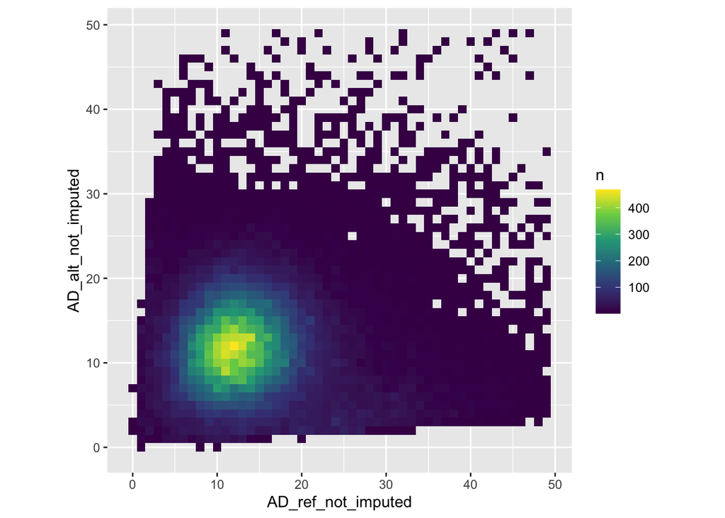

```r
new_fish %>%
  filter(GT012_not_imputed == 1,
         AD_ref_not_imputed < 50,
         AD_alt_not_imputed < 50
  ) %>%
  count(AD_ref_not_imputed, AD_alt_not_imputed) %>%
  ggplot(aes(x = AD_ref_not_imputed, y = AD_alt_not_imputed, fill = n)) +
  geom_tile() +
  scale_fill_viridis_c() +
  theme(aspect.ratio = 1)
```

That is kind of cool, and in the “stair-steps” along the side you can see the effect of the genotype likelihood model and base quality scores. You can have 32 copies of one allele and 2 of the other, and it still is going to call it a heterozygote. I suppose that some Base quality score recalibration would be worthwhile with such high read depth data (less so with really low read depth data, I imagine.)

I can’t help but think that some of these heterozygotes near the x=0 and y=0 axes are actually homozygous, but we can’t just filter them out like that, because those are also precisely the ones that you expect to be more likely to be called as homozygotes with a read depth of 2 or greater.

However, note that if these genotypes (called in the “not imputed” data set at full depth) really are all heterozygotes, then we we expect that the error rate (rate of calling them as homozygotes) from thinned data at read depths (sum of allele depths) of 0 or 1, should be the same across all the depth categories in the plot above. We can test that. First we count up the fraction of full-depth hets called as homozygotes in each of the AD cells:

```r
wrong_homoz_fracts <- new_fish %>%
  mutate(thinned_AD_sum = AD_ref_thinned + AD_alt_thinned) %>%
  filter(GT012_not_imputed == 1,
         AD_ref_not_imputed < 50,
         AD_alt_not_imputed < 50
  ) %>%
  filter(
    !is.na(GT012_thinned),
    thinned_AD_sum == 0 || thinned_AD_sum == 1
    ) %>%
  group_by(AD_ref_not_imputed, AD_alt_not_imputed, GT012_thinned) %>%
  tally() %>%
  mutate(ppn = n/sum(n)) %>%
  summarise(
    ppn_homoz = ifelse(!any(GT012_thinned == 1), 1, 1 - ppn[GT012_thinned == 1]),
    tot_n = sum(n)
    )
```

Then we plot them all:

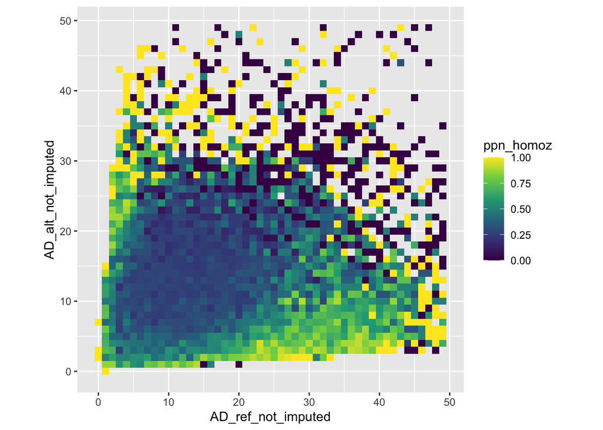

```r
ggplot(wrong_homoz_fracts, aes(x = AD_ref_not_imputed, y = AD_alt_not_imputed, fill = ppn_homoz)) +
  geom_tile() +
  scale_fill_viridis_c() +
  theme(aspect.ratio = 1)
```

And now let us restrict the plot to only those cells with at least 10 observations in them:

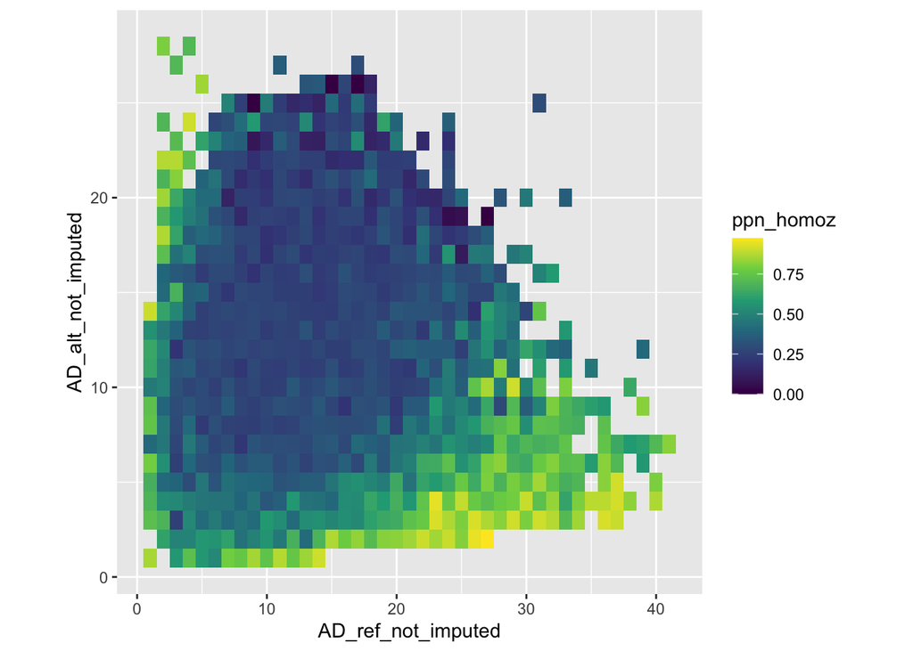

```r
wrong_homoz_fracts %>%
  filter(tot_n >= 10) %>%
ggplot(aes(x = AD_ref_not_imputed, y = AD_alt_not_imputed, fill = ppn_homoz)) +
  geom_tile() +
  scale_fill_viridis_c() +
  theme(aspect.ratio = 1)
```

So, there clearly are some genotypes called in the not_imputed data set that must be incorrect, while the calls from thinned an imputed data set are correct.

#### Allele depths in the full-depth imputed one

I just want to verify that we get roughly the same result with the full-depth imputed data set being used as the reference for heterozygotes. I expect that we will, which means that the incorrect genotype likelihoods are so strong that they cannot be countered by haplotypic neighborhood information.

```r
wrong_homoz_fracts_impfd <- new_fish %>%
  mutate(thinned_AD_sum = AD_ref_thinned + AD_alt_thinned) %>%
  filter(GT012_full_depth == 1,
         AD_ref_not_imputed < 50,
         AD_alt_not_imputed < 50
  ) %>%
  filter(
    !is.na(GT012_thinned),
    thinned_AD_sum == 0 || thinned_AD_sum == 1
    ) %>%
  group_by(AD_ref_not_imputed, AD_alt_not_imputed, GT012_thinned) %>%
  tally() %>%
  mutate(ppn = n/sum(n)) %>%
  summarise(
    ppn_homoz = ifelse(!any(GT012_thinned == 1), 1, 1 - ppn[GT012_thinned == 1]),
    tot_n = sum(n)
    )
```

Then we plot them all:

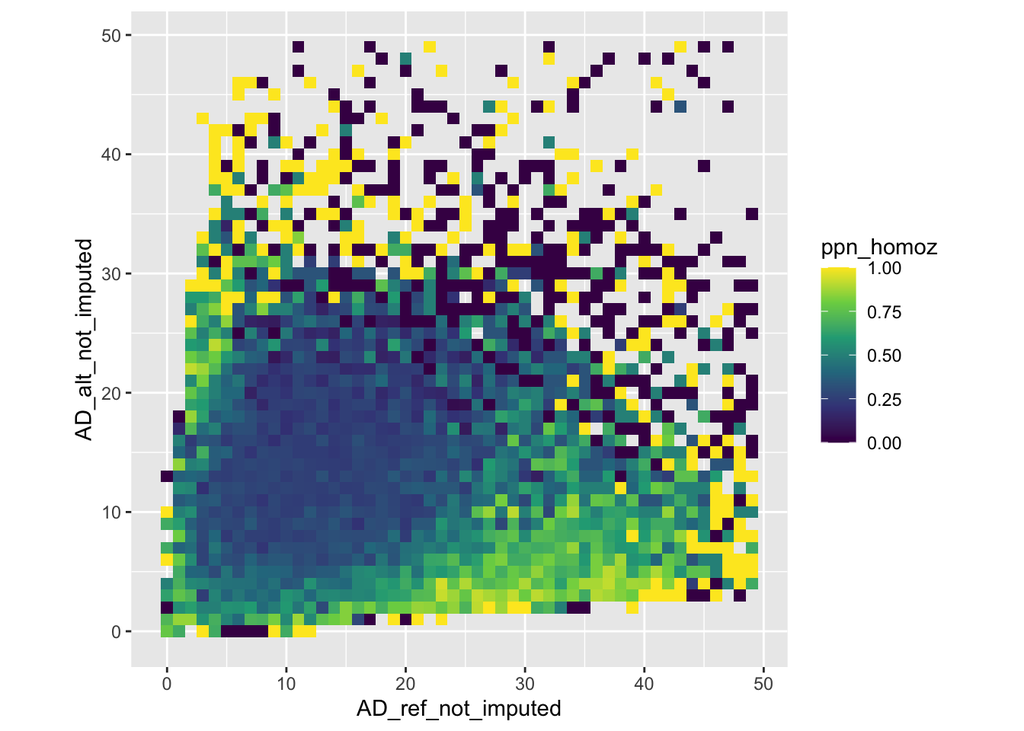

```r
ggplot(wrong_homoz_fracts_impfd, aes(x = AD_ref_not_imputed, y = AD_alt_not_imputed, fill = ppn_homoz)) +
  geom_tile() +
  scale_fill_viridis_c() +
  theme(aspect.ratio = 1)
```

And now let us restrict the plot to only those cells with at least 10 observations in them:

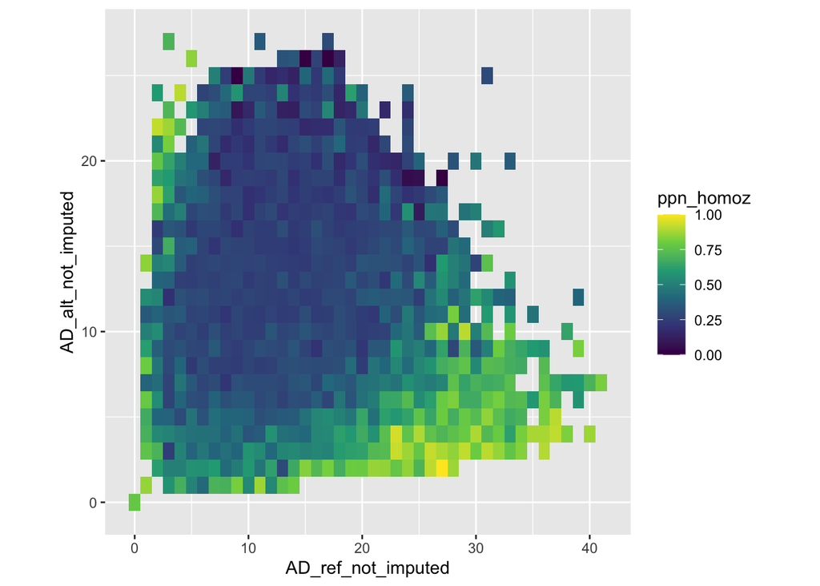

```r
wrong_homoz_fracts_impfd %>%
  filter(tot_n >= 10) %>%
ggplot(aes(x = AD_ref_not_imputed, y = AD_alt_not_imputed, fill = ppn_homoz)) +
  geom_tile() +
  scale_fill_viridis_c() +
  theme(aspect.ratio = 1)
```

So, we see pretty much the same thing with those guys.

**The take-home message is that some of the high-read depth heterozygote calls are almost certainly incorrect, and, as a consequence, the imputation error rates that we estimate here for our imputed data set by this method are almost certainly somewhat inflated. Nonetheless, we will use those error rates as is, and show that even under such high imputation error rates the effect on downstream analyses is minimal.**

## Focus on the RoSA

The main downstream uses of the imputed and phased sequences involve plotting trees from the sequences in the RoSA region. So, to assess the impact on those downstream analyses, we will estimate error rates specifically in the RoSA region. We expect these error rates to be somewhat lower because there are fewer heterozygotes in that region, as it includes two highly divergent haplotypic lineages.

```r
rfocus <- new_fish %>%
  filter(POS > 12.26e6 & POS < 12.29e6) %>%
  count(GT012_full_depth, GT012_thinned) %>%
  filter(!is.na(GT012_full_depth) & !is.na(GT012_thinned)) %>%
  group_by(GT012_full_depth) %>%
  mutate(ppn = n / sum(n))
rfocus
```

| GT012_full_depth | GT012_thinned | n | ppn |
| --- | --- | --- | --- |
| 0 | 0 | 1268 | 0.9814241486 |
| 0 | 1 | 23 | 0.0178018576 |
| 0 | 2 | 1 | 0.0007739938 |
| 1 | 0 | 39 | 0.2041884817 |
| 1 | 1 | 141 | 0.7382198953 |
| 1 | 2 | 11 | 0.0575916230 |
| 2 | 1 | 3 | 0.0102389078 |
| 2 | 2 | 290 | 0.9897610922 |

What we find there is a slightly lower rate of heterozygotes being called as homozygotes. However, as expected, the *overall* rate of genotype discordances is much lower, owing to the reduced fraction of heterozygotes:

```r
rfocus %>%
  mutate(correct = GT012_full_depth == GT012_thinned) %>%
  group_by(correct) %>%
  summarise(num = sum(n)) %>%
  mutate(ppn = num/sum(num))
```

| correct | num | ppn |
| --- | --- | --- |
| FALSE | 77 | 0.04335586 |
| TRUE | 1699 | 0.95664414 |

### Discordance rates for simulating imputation errors

We would like to estimate values that can be used for simulating errors into our existing imputed and phased data sets. The appropriate measure to use for that is the rate at which genotypes are called X in the thinned data sets and called Z in the full-depth data set. In other words, we want to be simulating errors at the rate at which observed (i.e. thinned) genotypes are incorrect We get this by rolling things up differently:

```r
rtfocus <- new_fish %>%
  filter(POS > 12.26e6 & POS < 12.29e6) %>%
  count(GT012_thinned, GT012_full_depth) %>%
  filter(!is.na(GT012_full_depth) & !is.na(GT012_thinned)) %>%
  group_by(GT012_thinned) %>%
  mutate(ppn = n / sum(n))
rtfocus
```

| GT012_thinned | GT012_full_depth | n | ppn |
| --- | --- | --- | --- |
| 0 | 0 | 1268 | 0.970160673 |
| 0 | 1 | 39 | 0.029839327 |
| 1 | 0 | 23 | 0.137724551 |
| 1 | 1 | 141 | 0.844311377 |
| 1 | 2 | 3 | 0.017964072 |
| 2 | 0 | 1 | 0.003311258 |
| 2 | 1 | 11 | 0.036423841 |
| 2 | 2 | 290 | 0.960264901 |

We have to keep in mind that GT012_thinned == 1 & GT012_full_depth == 2 is going to be a low category in this case cecause all of these high depth fish are fall-run, and the reference genome is from a fall-run fish, so this comparison lacks a lot of the ALT homozygotes.

For a quick comparison, let’s look at these values across a the whole 5.16 Mb:

```r
tfocus_5.16 <- new_fish %>%
  count(GT012_thinned, GT012_full_depth) %>%
  filter(!is.na(GT012_full_depth) & !is.na(GT012_thinned)) %>%
  group_by(GT012_thinned) %>%
  mutate(ppn = n / sum(n))
tfocus_5.16
```

| GT012_thinned | GT012_full_depth | n | ppn |
| --- | --- | --- | --- |
| 0 | 0 | 117379 | 0.882336581 |
| 0 | 1 | 15165 | 0.113995129 |
| 0 | 2 | 488 | 0.003668290 |
| 1 | 0 | 3242 | 0.065224826 |
| 1 | 1 | 43937 | 0.883955336 |
| 1 | 2 | 2526 | 0.050819837 |
| 2 | 0 | 268 | 0.006171276 |
| 2 | 1 | 6565 | 0.151173233 |
| 2 | 2 | 36594 | 0.842655491 |

Comparing the above two tables is informative. It shows us that, in the RoSA, if we have called something as homozygous, that is most likely correct: only a 3 to 3.6% rate that it might actually be a heterozygote. (And many of those are really solid heterozygotes with even ratios of ALT and REF reads:

```r
new_fish %>%
  filter(POS > 12.26e6 & POS < 12.29e6) %>%
  filter(!is.na(GT012_full_depth) & !is.na(GT012_thinned)) %>%
  filter(
    (GT012_thinned == 0 & GT012_full_depth == 1) |
    (GT012_thinned == 2 & GT012_full_depth == 1))
```

| ChromKey | POS | Indiv | spring_alt_freq | fall_alt_freq | GT012_thinned | GT012_full_depth | GT012_not_imputed | AD_ref_thinned | AD_ref_full_depth | AD_ref_not_imputed | AD_alt_thinned | AD_alt_full_depth | AD_alt_not_imputed |
| --- | --- | --- | --- | --- | --- | --- | --- | --- | --- | --- | --- | --- | --- |
| 1 | 12266853 | chinook_Battle.Creek.Sacramento.River_Schluter_GBC_001_CH1-2011_Male | 1.000000000 | 0.07142857 | 0 | 1 | 1 | 1 | 1 | 15 | 0 | 0 | 10 |
| 1 | 12271106 | chinook_Battle.Creek.Sacramento.River_Schluter_GBC_001_CH1-2011_Male | 1.000000000 | 0.75974026 | 2 | 1 | 1 | 0 | 0 | 11 | 1 | 1 | 10 |
| 1 | 12273395 | chinook_Battle.Creek.Sacramento.River_Schluter_GBC_001_CH1-2011_Male | 1.000000000 | 0.29220779 | 0 | 1 | 1 | 0 | 0 | 10 | 0 | 0 | 14 |
| 1 | 12285937 | chinook_Battle.Creek.Sacramento.River_Schluter_GBC_001_CH1-2011_Male | 0.084905660 | 0.90259740 | 2 | 1 | 1 | 0 | 0 | 9 | 0 | 0 | 15 |
| 1 | 12286299 | chinook_Battle.Creek.Sacramento.River_Schluter_GBC_001_CH1-2011_Male | 0.198113208 | 0.07142857 | 0 | 1 | 1 | 1 | 1 | 18 | 0 | 0 | 6 |
| 1 | 12266853 | chinook_Battle.Creek.Sacramento.River_Schluter_GBC_002_CH2-2011_Male | 1.000000000 | 0.07142857 | 0 | 1 | 1 | 1 | 1 | 15 | 0 | 0 | 2 |
| 1 | 12271155 | chinook_Battle.Creek.Sacramento.River_Schluter_GBC_002_CH2-2011_Male | 0.000000000 | 0.24025974 | 0 | 1 | 1 | 0 | 0 | 9 | 0 | 0 | 17 |
| 1 | 12286299 | chinook_Battle.Creek.Sacramento.River_Schluter_GBC_002_CH2-2011_Male | 0.198113208 | 0.07142857 | 0 | 1 | 1 | 3 | 3 | 10 | 0 | 0 | 2 |
| 1 | 12260992 | chinook_Battle.Creek.Sacramento.River_Schluter_GBC_003_CH3-2011_Male | 0.009433962 | 0.39610390 | 2 | 1 | 1 | 0 | 0 | 17 | 1 | 1 | 4 |
| 1 | 12263142 | chinook_Battle.Creek.Sacramento.River_Schluter_GBC_003_CH3-2011_Male | 0.000000000 | 0.42207792 | 2 | 1 | 1 | 0 | 0 | 19 | 0 | 0 | 17 |

[output cut: 40 more lines]

However, if we have called something as a heterozygote in the thinned data, 16% of the time it was called as a homozygote in the full depth data. So, in the RoSA, when we have imputed a homozygote we are “more likely to be correct” than if we imputed a heterozygote.  
That is interesting.

In the RoSA, we note that when fish were imputed to be hets but they are actually homozygous they are much more likely to be called as the reference homozygote than the alt. This might be owing to the fact that these are all fall run fish. At these loci, let’s look at the freqs of the ALT allele in spring and fall run:

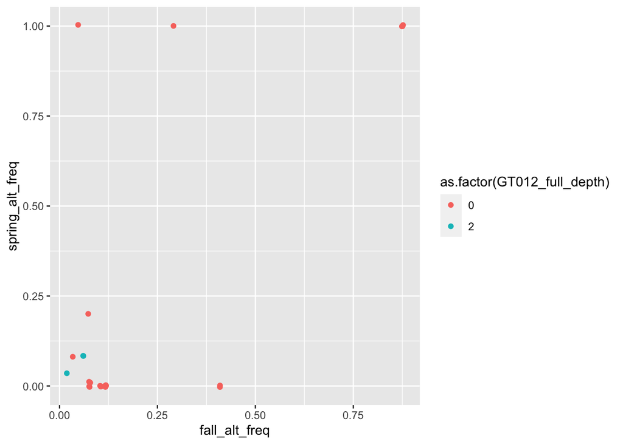

```r
new_fish %>%
  filter(POS > 12.26e6 & POS < 12.29e6) %>%
  filter(!is.na(GT012_full_depth) & !is.na(GT012_thinned)) %>%
  filter(GT012_thinned == 1) %>%
  filter(GT012_full_depth %in% c(0, 2)) %>%
  ggplot(aes(x = fall_alt_freq, y = spring_alt_freq, colour = as.factor(GT012_full_depth))) +
  geom_jitter()
```

Hmmm…so we don’t see a really clear pattern there. However, given that these were all fall-run fish and given that the rate at which thinned imputed 1’s are either full-depth 0’s or 1’s in the full 5.16 Mb region, I am inclined to set simulated discordance rates from 1 -> 0 and 1 -> 2 closer to one another.

So, given the values and evidence compiled here, I think that a suitable simulation to assess the effect of imputation error on our results in the RoSA would be to simulate errors such that probability of changes in the data are:

```r
est_rates_for_simulation <- tribble(
  ~imputed_genotype, ~simulated_new_genotype, ~rate,
  0, 0, 0.968,
0, 1, 0.03,
0, 2, 0.002,
1, 0, 0.09,
1, 1, 0.84,
1, 2, 0.07,
2, 0, 0.002,
2, 1, 0.036,
2, 2, 0.962
)
est_rates_for_simulation
```

| imputed_genotype | simulated_new_genotype | rate |
| --- | --- | --- |
| 0 | 0 | 0.968 |
| 0 | 1 | 0.030 |
| 0 | 2 | 0.002 |
| 1 | 0 | 0.090 |
| 1 | 1 | 0.840 |
| 1 | 2 | 0.070 |
| 2 | 0 | 0.002 |
| 2 | 1 | 0.036 |
| 2 | 2 | 0.962 |

And we will save that into outputs:

```r
write_rds(est_rates_for_simulation, path = "outputs/204/est_rates_for_simulation.rds")
```

In the next document (204-03) we will use those values to propagate changes to the imputed data set and observe the effects on the trees made.

# Following up on error rates

Though we use the rates estimated above to propagate simulated errors, into our data, I do suspect that those estimated rates are a little too high. That is fine for showing that even at such high error rates our inferred trees don’t change much, etc. But for my own knowledge about these processes, and to follow up further on my own hunch that the genotype likelihoods in many cases give too much weight to artificially low sequencing error rates, I want to follow up on this. (One thing I will note here is that this might provide a good argument for doing base quality score recalibration—I should investigate that).

## First, low-read-depth hets that are called homozygous at high depth

This is an interesting category, cuz it is not going in the direction we expect. Let’s have a look at it along the whole 5.16 Mb chunk. First whittle it down to calls where the “truth” was a homozygote of some sort and the thinned call was a heterogygote:

```r
wrong_thin_hets <- new_fish %>%
  filter(
    GT012_full_depth != 1,
    GT012_thinned == 1
  )
```

And now, let us look at the read depths there for the two different homozygote categories.

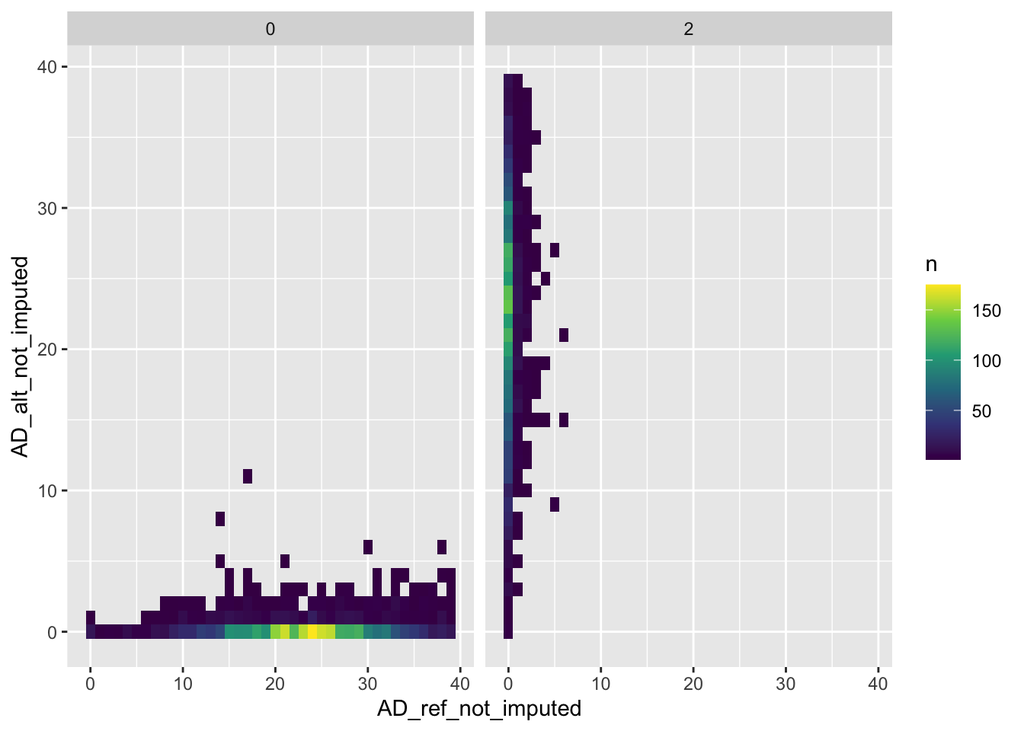

```r
wrong_thin_hets %>%
  count(GT012_full_depth, AD_ref_not_imputed, AD_alt_not_imputed) %>%
  filter(AD_ref_not_imputed < 40, AD_alt_not_imputed < 40) %>%
  ggplot(aes(x = AD_ref_not_imputed, AD_alt_not_imputed, fill = n)) +
  geom_tile() +
  facet_wrap(~GT012_full_depth) +
  scale_fill_viridis_c()
```

So, most of those are quite credibly not heterozygotes when looking at the full read depth information.

## Het miscall when we only use good high-depth sites

From my previous explorations, we saw clear evidence that some of the genotypes called as heterozygotes in the full-depth data are likely incorrect. So, now I am going to tally up the het miscalls from the thinned data, but only use the high read depth data that is part of that central cluster of things that look like we should have confidence in them: Let’s say we cut out the circle centered on 12, 12, and having radius 6. So that means it satisfies $(x-12)^2 + (y-12)^2 \leq r^2$. Let’s use that to pick those things out:

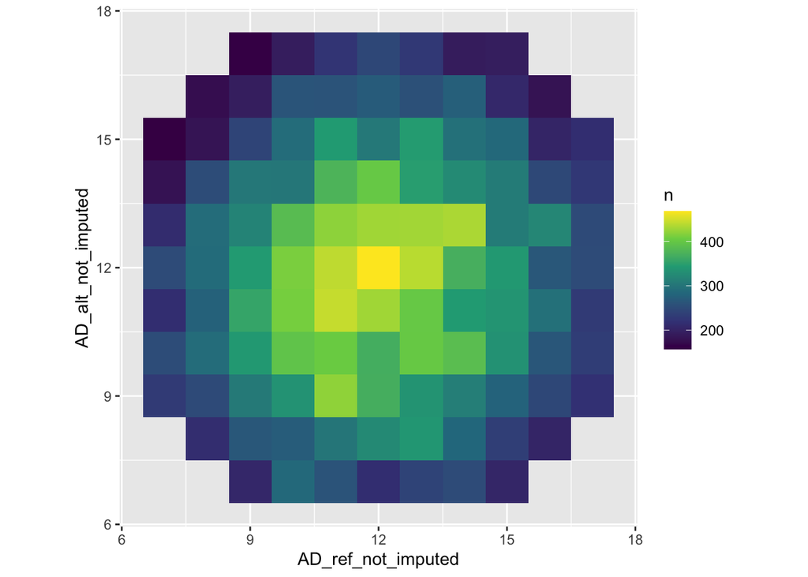

```r
good_ball_hets <- new_fish %>%
  filter(
    GT012_not_imputed == 1,
    (AD_ref_not_imputed - 12)^2 + (AD_alt_not_imputed - 12)^2 < 6^2
  )

# plot those, just to verify that we have what we want
good_ball_hets %>%
  count(AD_ref_not_imputed, AD_alt_not_imputed) %>%
  ggplot(aes(x = AD_ref_not_imputed, y = AD_alt_not_imputed, fill = n)) +
  geom_tile() +
  scale_fill_viridis_c() +
  theme(aspect.ratio = 1)
```

Yep, that looks right. Now, using only those calls as the “truth”, let’s see what our estimated het miscall rate is:

```r
good_ball_hets %>%
  count(GT012_full_depth, GT012_thinned) %>%
  filter(!is.na(GT012_full_depth) & !is.na(GT012_thinned)) %>%
  group_by(GT012_full_depth) %>%
  mutate(ppn = n / sum(n))
```

| GT012_full_depth | GT012_thinned | n | ppn |
| --- | --- | --- | --- |
| 1 | 0 | 5493 | 0.17579850 |
| 1 | 1 | 22787 | 0.72927735 |
| 1 | 2 | 2966 | 0.09492415 |

### Het miscall by depth

Let’s go ahead and break that down by thinned depth

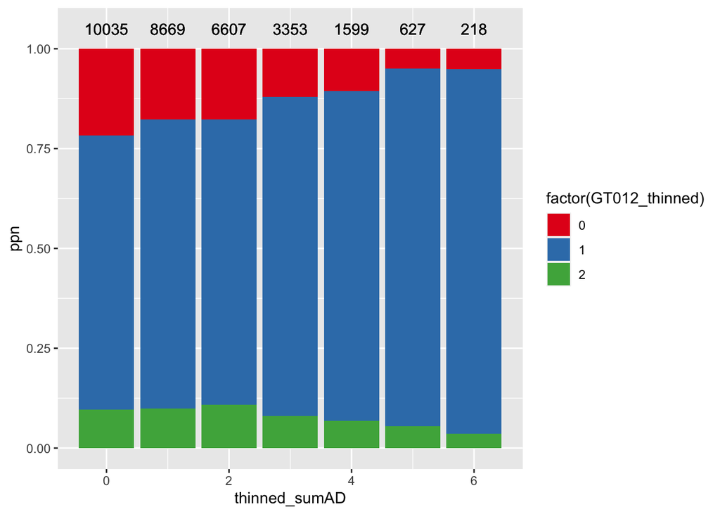

```r
good_ball_hets %>%
  mutate(thinned_sumAD = AD_ref_thinned + AD_alt_thinned) %>%
  group_by(thinned_sumAD, GT012_full_depth, GT012_thinned) %>%
  tally() %>%
  filter(!is.na(GT012_full_depth) & !is.na(GT012_thinned)) %>%
  group_by(thinned_sumAD) %>%
  mutate(
    ppn = n/sum(n),
    n_sum = sum(n)
    ) %>%
  filter(thinned_sumAD <= 6) %>%
  ggplot() +
  geom_col(aes(x = thinned_sumAD, y = ppn, fill = factor(GT012_thinned))) +
  scale_fill_brewer(palette = "Set1") +
  geom_text(mapping = aes(x = thinned_sumAD, y = 1.05, label = n_sum))
```

# Running Time

Running the code and rendering this notebook required approximately this much time on a Mac laptop of middling speed:

```r
Sys.time() - start_time
```

```
## Time difference of 2.039314 mins
```

Citations